# Monet Photo Stylization using a GAN

In this project, I'll be training a Generative Adversarial Network to apply Monet's style to a set of photos following the Kaggle Challenge found here (https://www.kaggle.com/competitions/gan-getting-started). The goal is to transfer the subtle artistic flair that comprises Monet's style onto photos so that they mimic his paintings. Given a dataset of some Monet paintings and a number of photographs, this project uses a generator to learn Monet's style and a discriminator to attempt to distinguish between real and generated paintings.

I'm not super familiar with TensorFlow and Keras, so in this project I'll be using pytorch. Because of this, I will be doing my operations on the .jpg images provided in the Kaggle dataset instead of the TFRecord files. This notebook was uploaded to the Kaggle challenge for scoring, but development was done locally using my RTX 3090.

```python
import pandas as pd
import numpy as np
import matplotlib.pyplot as plt
import seaborn as sns
import os
import glob
import torch
import torch.nn as nn
from torch.utils.data import Dataset
from torchvision import transforms

print(torch.cuda.get_device_name(0))
```

```
NVIDIA GeForce RTX 3090
```

## Loading Data

Because I'm using PyTorch for this project, I used the jpg datasets instead of the TFRecord data. The following cells parses all images from the Monet sample paintings and the photo samples into PyTorch `Dataset` objects. One thing to note here is the transformations `ToTensor` and `Normalize`. These convert the images into PyTorch tensors with pixel values from 0-1 (instead of 0-255 as typical RGB values) and scales the values to the range -1 to 1 which is required to match the expected input range of the GAN's generator and discriminator.

I'll discuss it later, but the generator I use applies a `tanh` activation that also outputs in the -1 to 1 range so this will keep training stable.

```python
class JPGFolderDataset(Dataset):
    def __init__(self, jpg_dir, transform=None):
        self.image_paths = glob.glob(os.path.join(jpg_dir, '*.jpg'))
        self.transform = transform if transform else transforms.ToTensor()

    def __len__(self):
        return len(self.image_paths)

    def __getitem__(self, idx):
        image_path = self.image_paths[idx]
        image = Image.open(image_path).convert('RGB')
        return self.transform(image)

# Don't forget to put the / before kaggle when uploading notebook
monet_dir = 'kaggle/input/gan-getting-started/monet_jpg'
photo_dir = 'kaggle/input/gan-getting-started/photo_jpg'

norm_tensor = transforms.Compose([
    transforms.ToTensor(),
    transforms.Normalize([0.5, 0.5, 0.5], [0.5, 0.5, 0.5])
])
monet_dataset = JPGFolderDataset(monet_dir, transform=norm_tensor)
photo_dataset = JPGFolderDataset(photo_dir, transform=norm_tensor)
```

## EDA/Preprocessing

My first step in EDA was double checking the consistency of image data. I verified that all photo and painting data was correctly parsed and was correctly formatted as 256 x 256 RGB. I display a sample of 8 images from each dataset just for visualization. I then evaluated RGB value distributions just to check out if there was any observable difference in the color palates of Monet and the photography samples.

The photo data has notable spikes across color channels at the high end of the spectrum suggesting presence of overexposure of images. Otherwise, the color intensities skew darker across all channels indicating large presence of darker photo regions which may be shadows or silhouettes. This seems to indicate that photos might have sharper contrast than Monet's paintings and stronger edge lighting. There seems to be overall a higher dynamic range.

These results show that color may be a very important part of Monet's stylization. Because of this, I emphasize color space in model training.

If I were to look a bit deeper, I would try to quantify differences in texture between photos and paintings, but I don't actually know much about art as I do color, so it would be difficult for me to interpret results.

```
Monet - Total images: 300
Monet - Widths: mean=256.0, std=0.0
Monet - Heights: mean=256.0, std=0.0
```

[figure not shown]

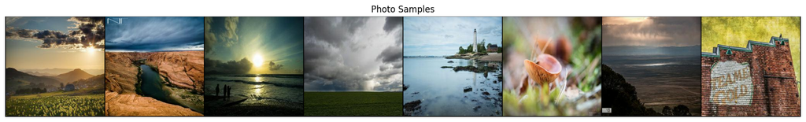

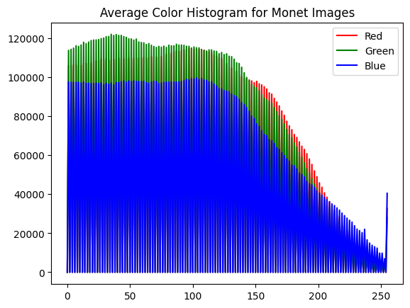

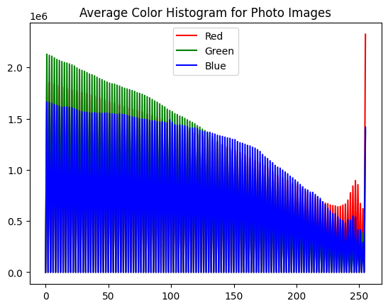

```python
from PIL import Image
from torchvision.utils import make_grid

def summarize_dataset(dataset, name):
    sizes = [Image.open(path).size for path in dataset.image_paths]
    widths, heights = zip(*sizes)
    print(f'{name} - Total images: {len(sizes)}')
    print(f'{name} - Widths: mean={np.mean(widths):.1f}, std={np.std(widths):.1f}')
    print(f'{name} - Heights: mean={np.mean(heights):.1f}, std={np.std(heights):.1f}')

def show_image_grid(dataset, title, n=8):
    images = [dataset[i] for i in range(n)]
    grid = make_grid(images, nrow=n, normalize=True)
    plt.figure(figsize=(20, 5))
    plt.imshow(grid.permute(1, 2, 0))
    plt.axis('off')
    plt.title(title)
    plt.show()

def plot_avg_rgb_histogram(dataset, name):
    r_hist = np.zeros(256)
    g_hist = np.zeros(256)
    b_hist = np.zeros(256)

    for i in range(len(dataset)):
        img = dataset[i].numpy()  # shape: C x H x W
        r, g, b = img[0].flatten(), img[1].flatten(), img[2].flatten()
        r_hist += np.histogram(r * 255, bins=256, range=(0, 255))[0]
        g_hist += np.histogram(g * 255, bins=256, range=(0, 255))[0]
        b_hist += np.histogram(b * 255, bins=256, range=(0, 255))[0]

    plt.plot(r_hist, color='r', label='Red')
    plt.plot(g_hist, color='g', label='Green')
    plt.plot(b_hist, color='b', label='Blue')
    plt.title(f'Average Color Histogram for {name}')
    plt.legend()
    plt.show()

summarize_dataset(monet_dataset, 'Monet')
summarize_dataset(photo_dataset, 'Photo')
print()
show_image_grid(monet_dataset, 'Monet Samples')
show_image_grid(photo_dataset, 'Photo Samples')
plot_avg_rgb_histogram(monet_dataset, 'Monet Images')
plot_avg_rgb_histogram(photo_dataset, 'Photo Images')
```

## Data Loader

Need this for loading data to GPU for model training. I use a batch size of 4 to limit GPU VRAM usage. Enabling shuffling reshuffles the datasets at the start of each training epoch which should promote generalization by removing any potential order bias.

```python
from torch.utils.data import DataLoader

monet_loader = DataLoader(
    monet_dataset,
    batch_size=4,
    shuffle=True,  # Shuffle Monet data every epoch
    num_workers=0
)

photo_loader = DataLoader(
    photo_dataset,
    batch_size=4,
    shuffle=True,  # Shuffle Photo data every epoch
    num_workers=0
)
```

## Model Building

The fun part. Gan structure involves a generator and a discriminator. I'll break them down separately.

### Generator

The generator starts with an initial convolution using a 7x7 kernel with reflection padding. Reflection padding is used to avoid sharp edge transitions caused by zero-padding. ReLU is used for activation without saturating gradients.

The two downsampling layers halve spatial resolution (256x256 -> 128 -> 64) allowing the network to learn more abstract/high level features. It also reduces memory consumption and gives the generator a latent bottleneck where global structure is learned.

The residual blocks (default six) exist to enable learning more complex representations for better generated outputs. They are used to avoid overfitting as well. To be honest this is the part of the generator architecture I understand the least and six felt like a good number to use and it worked pretty well.

The upsampling layers bring data back up to full 256x256 resolution using transposed convolutions instead of bilinear interpolation. I'm hoping this preserves style like brushstroke textures when upsampling.

The final convolution mirrors the first layer to smooth boundary artifacts. As mentioned earlier, the `tanh` outputs a -1 to 1 range matching the normalization used in dataset formation.

### Discriminator

The discriminator's purpose is identifying if an image is a real or generated Monet. Instead of producing a binary real/fake score, it gives a grid of decisions for parts of the image which should help the generator to produce locally realistic textures and not just nice overall images.

The first layer convolves the 3 channel input into 64 feature maps. The stride of 2 halves spatial size (256 -> 128). There's no normalization here yet. It just uses leaky ReLU activation. This layer should pick up low-level patterns like edges and color transitions without normalizing away important signals.

The intermediate layers double the number of channels for richer feature representation. It applies `InstanceNorm` as opposed to batch normalization to preserve per-image style. These layers should extract higher level texture features like brush strokes/reflections/other art stuff I'm not sure about.

The final output layer outputs a one channel feature map. Each pixel corresponds to a patch-based real/fake judgement as earlier described instead of passing a global decision for the whole image.

You might notice that across each layers I use spectral normalization on the convolution layers to constrain the Lipschitz contant. This should improve stability and prevent the discriminator from overpowering the generator. I found that this was strongly recommended for GANs using MSE or BCE loss (I use MSE).

```python
class ResidualBlock(nn.Module):
    def __init__(self, channels):
        super().__init__()
        self.block = nn.Sequential(
            nn.ReflectionPad2d(1),
            nn.Conv2d(channels, channels, kernel_size=3),
            nn.InstanceNorm2d(channels),
            nn.ReLU(inplace=True),
            nn.ReflectionPad2d(1),
            nn.Conv2d(channels, channels, kernel_size=3),
            nn.InstanceNorm2d(channels)
        )

    def forward(self, x):
        return x + self.block(x)

class Generator(nn.Module):
    def __init__(self, in_channels=3, out_channels=3, n_residuals=6):
        super().__init__()

        # Initial conv
        model = [
            nn.ReflectionPad2d(3),
            nn.Conv2d(in_channels, 64, kernel_size=7),
            nn.InstanceNorm2d(64),
            nn.ReLU(inplace=True)
        ]

        # Downsampling
        curr_dim = 64
        for _ in range(2):
            model += [
                nn.Conv2d(curr_dim, curr_dim * 2, kernel_size=3, stride=2, padding=1),
                nn.InstanceNorm2d(curr_dim * 2),
                nn.ReLU(inplace=True)
            ]
            curr_dim *= 2

        # Residual blocks
        for _ in range(n_residuals):
            model += [ResidualBlock(curr_dim)]

        # Upsampling
        for _ in range(2):
            model += [
                nn.ConvTranspose2d(curr_dim, curr_dim // 2, kernel_size=3, stride=2, padding=1, output_padding=1),
                nn.InstanceNorm2d(curr_dim // 2),
                nn.ReLU(inplace=True)
            ]
            curr_dim //= 2

        # Output layer
        model += [
            nn.ReflectionPad2d(3),
            nn.Conv2d(curr_dim, out_channels, kernel_size=7),
            nn.Tanh()
        ]

        self.model = nn.Sequential(*model)

    def forward(self, x):
        return self.model(x)

class Discriminator(nn.Module):
    def __init__(self, in_channels=3):
        super().__init__()
        channels = [64, 128, 256, 512]

        layers = []

        # First layer: no normalization
        layers += [
            nn.utils.spectral_norm(nn.Conv2d(in_channels, channels[0], kernel_size=4, stride=2, padding=1)),
            nn.LeakyReLU(0.2, inplace=True)
        ]

        # Intermediate layers
        in_c = channels[0]
        for out_c in channels[1:]:
            stride = 1 if out_c == channels[-1] else 2  # keep last conv stride=1
            layers += [
                nn.utils.spectral_norm(nn.Conv2d(in_c, out_c, kernel_size=4, stride=stride, padding=1)),
                nn.InstanceNorm2d(out_c),
                nn.LeakyReLU(0.2, inplace=True)
            ]
            in_c = out_c

        # Final layer: single channel output (patchwise real/fake)
        layers += [
            nn.utils.spectral_norm(nn.Conv2d(in_c, 1, kernel_size=4, stride=1, padding=1))  # output is not flattened
        ]

        self.model = nn.Sequential(*layers)

    def forward(self, x):
        return self.model(x)  # shape: (B, 1, H', W')
```

## Training

### Setup for Training

The optimizers I use for both generator and discriminator are Adam optimizers. They handle noisy and sparse gradients which can be useful for gAN training. I use a pretty standard learning rate of 2e-4. The betas I used were also recommended for GANs to reduce reliance on past gradients and to keep longer-term moving averages.

For my loss function, I use MSE loss instead of BCE because it tends to produce smoother gradients which should allow for more stable convergence.

Quick note: Before I get into the training loop, I import `autocast` and `GradScaler`. `autocast` dynamically enables training code to run with mixed precision (i.e. `float16` and `float32`) for relevant operations which HUGELY saves memory and speeds up training. I ran a few models without using `autocast` and was using up all 24 GB of VRAM on my GPU. This was significantly reduced when using `autocast` which also sped up training. Similarly, `GradScaler` helps with mixed precision training, preventing gradients from underflowing when using `float16` precision which `autocast` will cast certain values to.

### Training loop

After data is passed to the GPU using the data loaders discussed earlier, the discriminator is updated first. I add Gaussian noise to the discriminator inputs as a regularization trick to prevent overfitting. I average real and fake loss to avoid favouring either domain.

Generator updates are a bit more complicated. The generator wants to fool the discriminator, so loss is calculated against "real" labels. There are a few components to this loss. Total variation loss encourages smoothness in generated images (should reduce the "checkerboard" artifact from transpose convolutions). As I mentioned earlier in my EDA, I specifically include a color preservation loss term to ensure that generated images maintain the general color palatte of the source image. This should hopefully prevent drastic color distortions. The identity loss forces the generator to map Monet paintings back to themselves if given as input. It should prevent unnecessary over-stylization or color shifts.

As you can see in the lower code block, I train over 100 epochs which took about 20 minutes on my local hardware. Not too bad.

```python
generator = Generator().cuda()
discriminator = Discriminator().cuda()

g_optimizer = torch.optim.Adam(generator.parameters(), lr=2e-4, betas=(0.5, 0.999))
d_optimizer = torch.optim.Adam(discriminator.parameters(), lr=2e-4, betas=(0.5, 0.999))

adversarial_loss = nn.MSELoss()
```

```python
from tqdm import tqdm
from torch.amp import GradScaler, autocast

def add_noise(images, std=0.1):
    noise = torch.randn_like(images) * std
    return images + noise

def total_variation_loss(img):
    return torch.mean(torch.abs(img[:, :, :, :-1] - img[:, :, :, 1:])) + \
           torch.mean(torch.abs(img[:, :, :-1, :] - img[:, :, 1:, :]))

scaler = GradScaler('cuda')

def train_one_epoch(generator, discriminator, photo_loader, monet_loader,
                    g_optimizer, d_optimizer, criterion, device='cuda'):

    generator.train()
    discriminator.train()

    photo_iter = iter(photo_loader)
    monet_iter = iter(monet_loader)

    steps = min(len(photo_loader), len(monet_loader))

    for _ in tqdm(range(steps)):
        real_photos = next(photo_iter, None)
        real_monets = next(monet_iter, None)
        if real_photos is None or real_monets is None:
            break

        real_photos = real_photos.to(device)
        real_monets = real_monets.to(device)

        d_optimizer.zero_grad()

        with autocast('cuda'):  # Enable mixed-precision context
            # Add Gaussian noise for discriminator regularization
            real_preds = discriminator(add_noise(real_monets, std=0.1))
            fake_monets = generator(real_photos).detach()
            fake_preds = discriminator(add_noise(fake_monets, std=0.1))

            # Real = 1, Fake = 0
            real_labels = torch.ones_like(real_preds, device=device)
            fake_labels = torch.zeros_like(fake_preds, device=device)

            # Discriminator loss
            real_loss = criterion(real_preds, real_labels)
            fake_loss = criterion(fake_preds, fake_labels)
            d_loss = (real_loss + fake_loss) * 0.5

        # Backward and step with gradient scaler
        scaler.scale(d_loss).backward()
        scaler.step(d_optimizer)
        scaler.update()

        ### --- Train Generator ---
        g_optimizer.zero_grad()

        with autocast('cuda'):  # Mixed precision on generator too
            fake_monets = generator(real_photos)
            preds = discriminator(fake_monets)
            real_labels_for_g = torch.ones_like(preds, device=device)

            # Adversarial loss (G wants D to say "real")
            g_loss = criterion(preds, real_labels_for_g)

            # Total variation loss
            tv_weight = 1e-6
            g_loss += tv_weight * total_variation_loss(fake_monets)

            # Color preservation loss
            color_preservation_loss = torch.nn.L1Loss()
            color_loss_weight = 10.0
            color_loss = color_preservation_loss(fake_monets, real_photos)
            g_loss += color_loss_weight * color_loss

            # Identity loss (G(monet) ≈ monet)
            identity_weight = 10.0
            identity_loss_fn = torch.nn.L1Loss()
            identity_input = next(monet_iter, None)
            if identity_input is not None:
                identity_input = identity_input.to(device)
                same_monet = generator(identity_input)
                id_loss = identity_loss_fn(same_monet, identity_input)
                g_loss += identity_weight * id_loss

        # Backward and step with gradient scaler
        scaler.scale(g_loss).backward()
        scaler.step(g_optimizer)
        scaler.update()
    return g_loss.item(), d_loss.item()
```

```python
NUM_EPOCHS = 100

for epoch in range(NUM_EPOCHS):
    g_loss, d_loss = train_one_epoch(generator, discriminator,
                                     photo_loader, monet_loader,
                                     g_optimizer, d_optimizer,
                                     adversarial_loss)

    print(f'Epoch [{epoch+1}/{NUM_EPOCHS}] | G Loss: {g_loss:.4f} | D Loss: {d_loss:.4f}')
```

```
Epoch [1/100] | G Loss: 6.9924 | D Loss: 0.3587
```

```
Epoch [2/100] | G Loss: 4.6531 | D Loss: 0.2858
```

```
Epoch [3/100] | G Loss: 5.9040 | D Loss: 0.2747
```

```
Epoch [4/100] | G Loss: 7.0611 | D Loss: 0.8090
```

```
Epoch [5/100] | G Loss: 5.0199 | D Loss: 0.2555
```

```
Epoch [6/100] | G Loss: 4.6528 | D Loss: 0.2321
```

```
Epoch [7/100] | G Loss: 3.9912 | D Loss: 0.2009
```

```
Epoch [8/100] | G Loss: 5.0681 | D Loss: 0.2428
```

```
Epoch [9/100] | G Loss: 4.0304 | D Loss: 0.2933
```

```
Epoch [10/100] | G Loss: 4.3677 | D Loss: 0.2313
```

```
Epoch [11/100] | G Loss: 4.2907 | D Loss: 0.2278
```

```
Epoch [12/100] | G Loss: 4.0231 | D Loss: 0.1656
```

```
Epoch [13/100] | G Loss: 3.6480 | D Loss: 0.2006
```

```
Epoch [14/100] | G Loss: 3.7100 | D Loss: 0.2308
```

```
Epoch [15/100] | G Loss: 4.4494 | D Loss: 0.1943
```

```
Epoch [16/100] | G Loss: 3.6924 | D Loss: 0.3014
```

```
Epoch [17/100] | G Loss: 3.7047 | D Loss: 0.2081
```

```
Epoch [18/100] | G Loss: 4.0110 | D Loss: 0.2250
```

```
Epoch [19/100] | G Loss: 3.9136 | D Loss: 0.1606
```

```
Epoch [20/100] | G Loss: 3.3380 | D Loss: 0.1725
```

```
Epoch [21/100] | G Loss: 3.8163 | D Loss: 0.1457
```

```
Epoch [22/100] | G Loss: 4.5812 | D Loss: 0.2845
```

```
Epoch [23/100] | G Loss: 3.9698 | D Loss: 0.2984
```

```
Epoch [24/100] | G Loss: 3.9489 | D Loss: 0.1626
```

```
Epoch [25/100] | G Loss: 4.3716 | D Loss: 0.1705
```

```
Epoch [26/100] | G Loss: 3.6235 | D Loss: 0.1317
```

```
Epoch [27/100] | G Loss: 3.9062 | D Loss: 0.2533
```

```
Epoch [28/100] | G Loss: 3.9374 | D Loss: 0.2052
```

```
Epoch [29/100] | G Loss: 3.6599 | D Loss: 0.2334
```

```
Epoch [30/100] | G Loss: 4.2421 | D Loss: 0.1348
```

```
Epoch [31/100] | G Loss: 3.3831 | D Loss: 0.2588
```

```
Epoch [32/100] | G Loss: 3.3434 | D Loss: 0.1469
```

```
Epoch [33/100] | G Loss: 3.3564 | D Loss: 0.2549
```

```
Epoch [34/100] | G Loss: 4.1269 | D Loss: 0.2587
```

```
Epoch [35/100] | G Loss: 3.4781 | D Loss: 0.1511
```

```
Epoch [36/100] | G Loss: 4.4875 | D Loss: 0.1536
```

```
Epoch [37/100] | G Loss: 3.1709 | D Loss: 0.1596
```

```
Epoch [38/100] | G Loss: 3.9316 | D Loss: 0.1991
```

```
Epoch [39/100] | G Loss: 3.0761 | D Loss: 0.1621
```

```
Epoch [40/100] | G Loss: 3.5229 | D Loss: 0.1781
```

```
Epoch [41/100] | G Loss: 3.6904 | D Loss: 0.1633
```

```
Epoch [42/100] | G Loss: 3.8308 | D Loss: 0.1731
```

```
Epoch [43/100] | G Loss: 3.4700 | D Loss: 0.5560
```

```
Epoch [44/100] | G Loss: 3.2555 | D Loss: 0.1599
```

```
Epoch [45/100] | G Loss: 3.1609 | D Loss: 0.1615
```

```
Epoch [46/100] | G Loss: 3.6337 | D Loss: 0.1322
```

```
Epoch [47/100] | G Loss: 3.3194 | D Loss: 0.1675
```

```
Epoch [48/100] | G Loss: 3.4684 | D Loss: 0.2209
```

```
Epoch [49/100] | G Loss: 3.2269 | D Loss: 0.2697
```

```
Epoch [50/100] | G Loss: 3.2654 | D Loss: 0.1672
```

```
Epoch [51/100] | G Loss: 3.3210 | D Loss: 0.1332
```

```
Epoch [52/100] | G Loss: 2.8301 | D Loss: 0.3010
```

```
Epoch [53/100] | G Loss: 3.9694 | D Loss: 0.1731
```

```
Epoch [54/100] | G Loss: 3.5831 | D Loss: 0.1121
```

```
Epoch [55/100] | G Loss: 3.3119 | D Loss: 0.1967
```

```
Epoch [56/100] | G Loss: 3.2600 | D Loss: 0.1984
```

```
Epoch [57/100] | G Loss: 3.7449 | D Loss: 0.1928
```

```
Epoch [58/100] | G Loss: 2.8284 | D Loss: 0.2596
```

```
Epoch [59/100] | G Loss: 2.7203 | D Loss: 0.2247
```

```
Epoch [60/100] | G Loss: 3.5912 | D Loss: 0.2350
```

```
Epoch [61/100] | G Loss: 3.2545 | D Loss: 0.1299
```

```
Epoch [62/100] | G Loss: 2.9362 | D Loss: 0.1482
```

```
Epoch [63/100] | G Loss: 3.6798 | D Loss: 0.1523
```

```
Epoch [64/100] | G Loss: 3.7247 | D Loss: 0.1169
```

```
Epoch [65/100] | G Loss: 3.1365 | D Loss: 0.1692
```

```
Epoch [66/100] | G Loss: 3.3224 | D Loss: 0.0803
```

```
Epoch [67/100] | G Loss: 3.4454 | D Loss: 0.1295
```

```
Epoch [68/100] | G Loss: 3.4292 | D Loss: 0.1057
```

```
Epoch [69/100] | G Loss: 3.6632 | D Loss: 0.2983
```

```
Epoch [70/100] | G Loss: 4.0863 | D Loss: 0.1958
```

```
Epoch [71/100] | G Loss: 3.4097 | D Loss: 0.3301
```

```
Epoch [72/100] | G Loss: 4.1235 | D Loss: 0.2614
```

```
Epoch [73/100] | G Loss: 3.2721 | D Loss: 0.0908
```

```
Epoch [74/100] | G Loss: 3.0710 | D Loss: 0.2452
```

```
Epoch [75/100] | G Loss: 3.0203 | D Loss: 0.1668
```

```
Epoch [76/100] | G Loss: 2.6486 | D Loss: 0.2444
```

```
Epoch [77/100] | G Loss: 2.9902 | D Loss: 0.2373
```

```
Epoch [78/100] | G Loss: 3.1378 | D Loss: 0.2022
```

```
Epoch [79/100] | G Loss: 3.3757 | D Loss: 0.2012
```

```
Epoch [80/100] | G Loss: 3.2507 | D Loss: 0.1584
```

```
Epoch [81/100] | G Loss: 2.9312 | D Loss: 0.1556
```

```
Epoch [82/100] | G Loss: 3.1303 | D Loss: 0.1575
```

```
Epoch [83/100] | G Loss: 2.8187 | D Loss: 0.3293
```

```
Epoch [84/100] | G Loss: 3.2807 | D Loss: 0.2667
```

```
Epoch [85/100] | G Loss: 3.4733 | D Loss: 0.1145
```

```
Epoch [86/100] | G Loss: 3.0234 | D Loss: 0.3459
```

```
Epoch [87/100] | G Loss: 2.5338 | D Loss: 0.1394
```

```
Epoch [88/100] | G Loss: 3.1376 | D Loss: 0.1685
```

```
Epoch [89/100] | G Loss: 2.8345 | D Loss: 0.1235
```

```
Epoch [90/100] | G Loss: 3.3547 | D Loss: 0.0720
```

```
Epoch [91/100] | G Loss: 3.8972 | D Loss: 0.1546
```

```
Epoch [92/100] | G Loss: 3.0086 | D Loss: 0.1148
```

```
Epoch [93/100] | G Loss: 2.9574 | D Loss: 0.1462
```

```
Epoch [94/100] | G Loss: 2.6550 | D Loss: 0.1918
```

```
Epoch [95/100] | G Loss: 2.9575 | D Loss: 0.1545
```

```
Epoch [96/100] | G Loss: 3.1825 | D Loss: 0.1308
```

```
Epoch [97/100] | G Loss: 2.7607 | D Loss: 0.1240
```

```
Epoch [98/100] | G Loss: 2.8825 | D Loss: 0.1779
```

```
Epoch [99/100] | G Loss: 3.6521 | D Loss: 0.1019
```

```
Epoch [100/100] | G Loss: 3.0949 | D Loss: 0.1231
```

## Conclusions: Applying the Trained Model

Here I apply the model to the photos data and hopefully stylize them as Monets. As a disclaimer, I'm no art critic. I can tell that the model definitely did something to the photos, but I can't say how much it actually applied Monet's style. There's definitely a slight shift in color tone that seems to emphasize reds a bit more and increase warmth of white areas (especially in that fifth example photo below). There's also definitely some sort of texture applied, but I personally don't think it looks like brush strokes. It kinda looks more like dithering to me. I'm not really sure what to call it. To my human eye, I definitely wouldn't say these outputs look like paintings, but I'm also not quite sure how I would change my model to improve that. Perhaps a deeper residual block in my generator would help. Overall I'm pretty happy with my scores. My best score puts me at 27th on the leaderboard at time of writing (April 25, 2025).

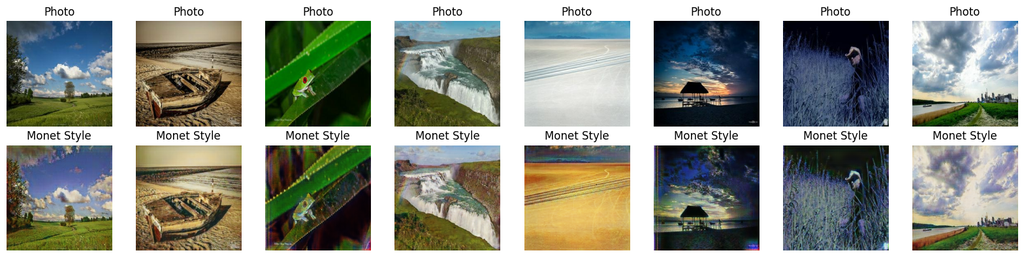

```python
import random

def denormalize(tensor):
    # Convert from [-1, 1] back to [0, 1]
    return (tensor + 1.0) / 2.0

def visualize_monet_styling(generator, photo_dataset, device='cuda', n=8):
    generator.eval()

    indices = random.sample(range(len(photo_dataset)), n)
    photo_imgs = torch.stack([photo_dataset[i] for i in indices]).to(device)

    with torch.no_grad():
        fake_monets = generator(photo_imgs)

    # De-normalize
    photo_imgs = denormalize(photo_imgs).cpu()
    fake_monets = denormalize(fake_monets).cpu()

    # Plot side by side
    plt.figure(figsize=(16, 4))
    for i in range(n):
        # Original photo
        plt.subplot(2, n, i + 1)
        plt.imshow(photo_imgs[i].permute(1, 2, 0).clamp(0, 1))
        plt.axis('off')
        plt.title('Photo')

        # Stylized Monet
        plt.subplot(2, n, n + i + 1)
        plt.imshow(fake_monets[i].permute(1, 2, 0).clamp(0, 1))
        plt.axis('off')
        plt.title('Monet Style')

    plt.tight_layout()
    plt.show()

visualize_monet_styling(generator, photo_dataset, device='cuda')
```

## Final Output

This chunk is just for the competition submission. Applies the model to the photos folder and zips everything into `images.zip`.

```python
import os
import zipfile
from torchvision.utils import save_image

# Output directory
output_dir = 'images'
os.makedirs(output_dir, exist_ok=True)

# Inference loader (no shuffle, no augmentations)
inference_loader = DataLoader(photo_dataset, batch_size=1, shuffle=False)

# Put model in eval mode
generator.eval()

# Disable gradients for inference
with torch.no_grad():
    for i, photo in enumerate(tqdm(inference_loader)):
        photo = photo.to('cuda')

        with torch.amp.autocast('cuda'):  # use autocast for memory savings
            fake_monet = generator(photo)

        # Denormalize [-1, 1] → [0, 1]
        fake_monet = (fake_monet + 1.0) / 2.0

        # Save image
        filename = os.path.join(output_dir, f'{i}.jpg')
        save_image(fake_monet, filename)

# Zip the folder
zip_filename = 'images.zip'
with zipfile.ZipFile(zip_filename, 'w') as zipf:
    for root, _, files in os.walk(output_dir):
        for file in files:
            filepath = os.path.join(root, file)
            zipf.write(filepath, arcname=file)  # strip folder in archive

print(f'Stylized images saved and zipped to {zip_filename}')
```

[output not shown]

```
Stylized images saved and zipped to images.zip
```

## Don't run this

It empties VRAM which I needed to do after a few iterations maxing out my GPU.

```python
torch.cuda.empty_cache()
```